# STAT 1210

Chapter 11 Homework: The Normal Distributions

Fall 2026

### Question $1$

A veterinary physiology team models the resting heart rate $H$ of healthy adult domestic cats as approximately Normal with mean $160$ beats per minute and standard deviation $20$ beats per minute.

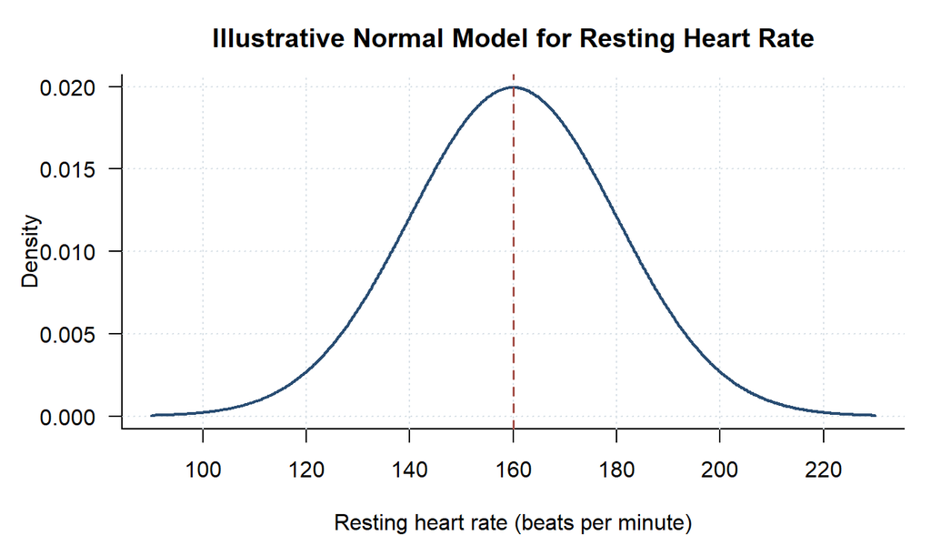

1. Write the model using the notation $H\sim N(\mu,\sigma)$.
2. What are the mean and median of this model?
3. At what two heart rates are the inflection points located?
4. What proportion of the total area lies to the left of $160$ beats per minute?
5. If the standard deviation were reduced from $20$ to $12$ beats per minute while the mean remained unchanged, how would the curve change?

**Show solution**

1. The model is

   $$H\sim N(160,20)$$
2. A Normal distribution is symmetric around its mean, so the mean and median are both $160$ beats per minute.
3. The inflection points occur at $\mu-\sigma$ and $\mu+\sigma$:

   $$160-20=140$$

   $$160+20=180$$

   The inflection points are located at $140$ and $180$ beats per minute.
4. Symmetry places half of the total area on each side of the mean, so

   $$P(H<160)=0.5$$
5. The curve would become narrower and taller because values would be more concentrated around $160$. Its total area would remain equal to $1$.

### Question $2$

The gestation length $G$ of a particular breed of dog is modelled as approximately Normal with mean $63$ days and standard deviation $2$ days.

1. Use the $68$–$95$–$99.7$ rule to find the interval containing approximately the middle $68\%$ of gestation lengths.
2. Find the interval containing approximately the middle $95\%$.
3. Find the interval containing approximately the middle $99.7\%$.
4. Approximately what percentage of gestation lengths exceed $67$ days?
5. Approximately what percentage fall below $61$ days?

**Show solution**

1. The middle $68\%$ lies within one standard deviation of the mean:

   $$63-2=61$$

   $$63+2=65$$

   Approximately $68\%$ of gestation lengths lie between $61$ and $65$ days.
2. The middle $95\%$ lies within two standard deviations:

   $$63-2(2)=59$$

   $$63+2(2)=67$$

   Approximately $95\%$ lie between $59$ and $67$ days.
3. The middle $99.7\%$ lies within three standard deviations:

   $$63-3(2)=57$$

   $$63+3(2)=69$$

   Approximately $99.7\%$ lie between $57$ and $69$ days.
4. The value $67$ is two standard deviations above the mean. The middle $95\%$ leaves $5\%$ in the two tails, so

   $$P(G>67)\approx\frac{0.05}{2}=0.025$$

   Approximately $2.5\%$ exceed $67$ days.
5. The value $61$ is one standard deviation below the mean. The middle $68\%$ leaves $32\%$ outside, so

   $$P(G<61)\approx\frac{0.32}{2}=0.16$$

   Approximately $16\%$ fall below $61$ days.

### Question $3$

Wildlife researchers compare two unusually large animals with their respective reference populations.

- A bald eagle has a wingspan of $2.12$ m. Adult wingspans in its reference population have mean $1.95$ m and standard deviation $0.10$ m.
- A red fox has a mass of $7.8$ kg. Adult masses in its reference population have mean $6.5$ kg and standard deviation $0.9$ kg.
1. Calculate the z-score for the eagle’s wingspan.
2. Calculate the z-score for the fox’s mass.
3. Interpret each z-score in context.
4. Which animal has the more unusual high measurement relative to its reference population?
5. Why would directly comparing $2.12$ with $7.8$ be meaningless?

**Show solution**

1. The eagle’s z-score is

   $$z=\frac{2.12-1.95}{0.10}=1.70$$
2. The fox’s z-score is

   $$z=\frac{7.8-6.5}{0.9}\approx1.44$$
3. The eagle’s wingspan is $1.70$ standard deviations above its population mean. The fox’s mass is approximately $1.44$ standard deviations above its population mean.
4. The eagle has the more unusual high measurement because $1.70>1.44$.
5. The raw measurements use different units and describe different characteristics. Z-scores provide a unitless common scale for comparing relative positions.

### Question $4$

The recovery time $R$ after a routine veterinary anaesthetic procedure is modelled as approximately Normal with mean $45$ minutes and standard deviation $6$ minutes.

Use a cumulative left-tail Standard Normal table to answer the following questions.

1. What are the z-scores corresponding to $39$ minutes and $57$ minutes?
2. What is the probability that recovery takes between $39$ and $57$ minutes, $P(39<R<57)$?
3. What is the probability that recovery takes less than $39$ minutes, $P(R<39)$?
4. What is the probability that recovery takes more than $57$ minutes, $P(R>57)$?
5. Among $400$ similar procedures, how many recovery times would be expected to fall between $39$ and $57$ minutes?
6. Why are the probabilities calculated using the z-table still approximations?

**Show solution**

1. The standardized boundaries are

   $$z_{\mathrm{lower}}=\frac{39-45}{6}=-1.00$$

   $$z_{\mathrm{upper}}=\frac{57-45}{6}=2.00$$

   Thus, $39$ minutes is one standard deviation below the mean, and $57$ minutes is two standard deviations above the mean.
2. We want $P(39<R<57)$. The table gives

   $$P(Z\le-1.00)=0.1587
   \qquad
   P(Z\le2.00)=0.9772$$

   Subtracting the cumulative areas gives

   $$\begin{aligned}
   P(39<R<57)
   &=P(-1.00<Z<2.00)\\
   &=P(Z\le2.00)-P(Z\le-1.00)\\
   &\approx0.9772-0.1587\\
   &=\boxed{0.8185}
   \end{aligned}$$

   Approximately $81.85\%$ of recovery times fall between $39$ and $57$ minutes.
3. We want the left-tail probability below $39$ minutes. Using symmetry and the table entry $P(Z\le1.00)=0.8413$,

   $$\begin{aligned}
   P(R<39)
   &=P(Z<-1.00)\\
   &=1-P(Z\le1.00)\\
   &\approx1-0.8413\\
   &=\boxed{0.1587}
   \end{aligned}$$

   Approximately $15.87\%$ of recovery times are less than $39$ minutes.
4. We want the right-tail probability above $57$ minutes. Using the complement rule,

   $$\begin{aligned}
   P(R>57)
   &=P(Z>2.00)\\
   &=1-P(Z\le2.00)\\
   &\approx1-0.9772\\
   &=\boxed{0.0228}
   \end{aligned}$$

   Approximately $2.28\%$ of recovery times exceed $57$ minutes.
5. Multiplying the number of procedures by the probability from Part $2$ gives the expected count:

   $$400(0.8185)=327.4$$

   Approximately $327$ procedures would be expected to have recovery times between $39$ and $57$ minutes. This is an expected count, not a guarantee of the observed count.
6. The z-table rounds probabilities to a limited number of decimal places. Also, the Normal distribution is an approximate model for actual recovery times.

   The table gives more precise Normal probabilities than the rounded percentages in the $68$–$95$–$99.7$ rule.

### Question $5$

In an illustrative veterinary reference population, serum sodium concentration $S$ is modelled as Normal with mean $145$ mmol/L and standard deviation $4$ mmol/L.

1. Write the model in Normal notation.
2. Calculate $P(S<137)$ using R.
3. Calculate $P(S>153)$ using R.
4. Calculate the probability that a concentration lies outside the interval from $137$ to $153$ mmol/L.
5. Among $800$ independent measurements from this reference population, approximately how many would be expected outside this interval?
6. Compare the exact result with the approximation from the $68$–$95$–$99.7$ rule.

**Show solution**

1. The model is

   $$S\sim N(145,4)$$
2. The lower boundary is two standard deviations below the mean. R gives

   ```r
   pnorm(q = 137, mean = 145, sd = 4)
   ```

   ```
   ## [1] 0.02275013
   ```

   Therefore,

   $$P(S<137)\approx0.0228$$
3. The right-tail probability is

   ```r
   pnorm(q = 153, mean = 145, sd = 4, lower.tail = FALSE)
   ```

   ```
   ## [1] 0.02275013
   ```

   Therefore,

   $$P(S>153)\approx0.0228$$
4. The two tail regions are disjoint, so

   $$P(S<137\text{ or }S>153)
   \approx0.0228+0.0228
   =0.0455$$
5. The expected number is

   $$800(0.0455)\approx36.4$$

   Approximately $36$ measurements would be expected outside the interval.
6. The empirical rule estimates that $5\%$ lies outside two standard deviations. The exact Normal result is approximately $4.55\%$, which is close because the empirical rule is rounded.

### Question $6$

The wing length $W$ of an adult songbird species is modelled as approximately Normal with mean $74$ mm and standard deviation $5.5$ mm.

1. Standardize the boundaries $68$ mm and $82$ mm.
2. Use R to calculate $P(68<W<82)$.
3. What proportion of birds are expected to have wing lengths outside this interval?
4. In a random sample of $350$ birds, approximately how many would be expected to have wing lengths between $68$ and $82$ mm?
5. Explain why $P(68<W<82)=P(68\leq W\leq82)$ under this model.

**Show solution**

1. The standardized boundaries are

   $$z_1=\frac{68-74}{5.5}\approx-1.09$$

   $$z_2=\frac{82-74}{5.5}\approx1.45$$
2. The interval probability is calculated by subtracting cumulative areas:

   ```r
   pnorm(q = 82, mean = 74, sd = 5.5) -
     pnorm(q = 68, mean = 74, sd = 5.5)
   ```

   ```
   ## [1] 0.789446
   ```

   Therefore,

   $$P(68<W<82)\approx0.7894$$
3. The probability outside the interval is

   $$1-0.7894=0.2106$$

   Approximately $21.06\%$ lie outside the interval.
4. The expected number is

   $$350(0.7894)\approx276.3$$

   Approximately $276$ birds would be expected in the interval.
5. A single exact value has probability $0$ in a continuous model. Including or excluding the endpoints therefore does not change the area or probability.

### Question $7$

A manufacturing process fills veterinary vaccine vials. The fill volume $V$ is modelled as Normal with mean $10.00$ mL and standard deviation $0.12$ mL.

1. Find the lower and upper boundaries of the central $98\%$ of fill volumes.
2. What fill volume marks the lowest $5\%$ of the distribution?
3. A vial contains $9.75$ mL. Calculate its z-score.
4. Use R to find the percentile rank of a $9.75$ mL fill.
5. Based only on this model, is $9.75$ mL below the lower $5\%$ boundary?

**Show solution**

1. The central $98\%$ leaves $1\%$ in each tail. The boundaries are the $1$st and $99$th percentiles:

   ```r
   qnorm(c(0.01, 0.99), mean = 10.00, sd = 0.12)
   ```

   ```
   ## [1]  9.720838 10.279162
   ```

   The central $98\%$ extends approximately from $9.721$ mL to $10.279$ mL.
2. The lower $5\%$ boundary is

   ```r
   qnorm(p = 0.05, mean = 10.00, sd = 0.12)
   ```

   ```
   ## [1] 9.802618
   ```

   The boundary is approximately $9.803$ mL.
3. The z-score is

   $$z=\frac{9.75-10.00}{0.12}\approx-2.08$$
4. The cumulative probability is

   ```r
   pnorm(q = 9.75, mean = 10.00, sd = 0.12)
   ```

   ```
   ## [1] 0.01861043
   ```

   Approximately $0.0186$, or $1.86\%$, of fills are at or below $9.75$ mL. The vial is approximately at the $1.86$th percentile.
5. Yes. Since $9.75<9.803$, the vial lies below the model’s lower $5\%$ boundary. This statistical statement does not by itself determine whether the vial satisfies a regulatory requirement.

### Question $8$

Piglet birth weight $B$ is modelled as Normal with mean $1.40$ kg and standard deviation $0.25$ kg. Use the Standard Normal table values below.

| $z$ | $N(z)=P(Z\leq z)$ |
| --- | --- |
| $1.40$ | $0.9192$ |
| $1.60$ | $0.9452$ |
| $2.00$ | $0.9772$ |

1. Convert $1.05$ kg and $1.80$ kg to z-scores.
2. Use the table and symmetry to calculate $P(1.05<B<1.80)$.
3. Calculate $P(B>1.90)$ using the table.
4. In a population of $2500$ piglets, approximately how many would be expected to weigh more than $1.90$ kg?
5. Check the interval probability from Part $2$ using one line of R code.

**Show solution**

1. The standardized boundaries are

   $$z_1=\frac{1.05-1.40}{0.25}=-1.40$$

   $$z_2=\frac{1.80-1.40}{0.25}=1.60$$
2. The table does not list the negative value directly, so symmetry gives

   $$N(-1.40)=1-N(1.40)=1-0.9192=0.0808$$

   Therefore,

   $$\begin{aligned}
   P(1.05<B<1.80)
   &=P(-1.40<Z<1.60)\\
   &=N(1.60)-N(-1.40)\\
   &=0.9452-0.0808\\
   &=0.8644
   \end{aligned}$$
3. A weight of $1.90$ kg has z-score

   $$z=\frac{1.90-1.40}{0.25}=2.00$$

   The right-tail probability is

   $$P(B>1.90)=1-N(2.00)=1-0.9772=0.0228$$
4. The expected number is

   $$2500(0.0228)=57$$

   Approximately $57$ piglets would be expected above $1.90$ kg.
5. The R check is

   ```r
   pnorm(1.80, mean = 1.40, sd = 0.25) -
     pnorm(1.05, mean = 1.40, sd = 0.25)
   ```

   ```
   ## [1] 0.864444
   ```

   The result is approximately $0.8644$.

### Question $9$

For one narrowly defined category of automobile repairs, an insurer uses an illustrative Normal model for claim amount $C$ with mean $\$2200$ and standard deviation $\$350$.

1. What claim amount marks the beginning of the highest $7\%$ of claims? Write the probability statement before calculating the boundary.
2. What claim amount marks the lowest $3\%$ of claims?
3. What proportion of claims lies between the two boundaries from Parts $1$ and $2$?
4. Among $4000$ claims, approximately how many would be expected to fall outside those two boundaries?
5. Explain why the insurer should examine actual claim data before relying on this Normal model.

**Show solution**

1. Let $u$ be the upper boundary. The highest $7\%$ satisfies

   $$P(C>u)=0.07$$

   Therefore, the cumulative area to the left is

   $$P(C\leq u)=0.93$$

   ```r
   qnorm(p = 0.93, mean = 2200, sd = 350)
   ```

   ```
   ## [1] 2716.527
   ```

   The upper boundary is approximately $\$2716.53$.
2. Let $\ell$ be the lower boundary. It satisfies

   $$P(C\leq\ell)=0.03$$

   ```r
   qnorm(p = 0.03, mean = 2200, sd = 350)
   ```

   ```
   ## [1] 1541.722
   ```

   The lower boundary is approximately $\$1541.72$.
3. The lower tail contains $3\%$ and the upper tail contains $7\%$. Therefore,

   $$P(\ell<C<u)=1-0.03-0.07=0.90$$

   Approximately $90\%$ of claims lie between the two boundaries.
4. The proportion outside is $0.10$, so

   $$4000(0.10)=400$$

   Approximately $400$ claims would be expected outside the boundaries.
5. Repair claims are restricted to nonnegative values and can be right-skewed because a small number of claims may be very expensive. The insurer should examine a histogram or density plot and look for skewness, subgroups and unusual claims before treating the Normal model as reasonable.

### Question $10$

A conservation hatchery models the fork length $L$ of Atlantic salmon smolts as Normal with mean $145$ mm and standard deviation $12$ mm. Smolts in the lowest $10\%$ are classified as **small**, while smolts in the highest $5\%$ are classified as **large**.

1. Write probability statements defining the small and large cutoffs.
2. Calculate both cutoff lengths using R.
3. Under the original model, what proportion of smolts is neither small nor large?
4. Among $1200$ smolts, how many would be expected in each of the three classifications?
5. In a later season, the mean length increases to $149$ mm while the standard deviation remains $12$ mm. If the original numerical cutoffs are retained, calculate the new proportions classified as small and large.
6. Compare the new classification proportions with the original proportions.
7. What cutoff lengths should be used in the later season if the hatchery wants to preserve the lowest-$10\%$ and highest-$5\%$ definitions?
8. Identify one scientific limitation of using this model to classify future smolts.

**Show solution**

1. Let $\ell$ be the small cutoff and $u$ be the large cutoff. They satisfy

   $$P(L\leq\ell)=0.10$$

   $$P(L>u)=0.05$$

   Equivalently,

   $$P(L\leq u)=0.95$$
2. The cutoffs are

   ```r
   small_cutoff <- qnorm(0.10, mean = 145, sd = 12)
   large_cutoff <- qnorm(0.95, mean = 145, sd = 12)
   c(small = small_cutoff, large = large_cutoff)
   ```

   ```
   ##    small    large
   ## 129.6214 164.7382
   ```

   The small cutoff is approximately $129.62$ mm and the large cutoff is approximately $164.74$ mm.
3. The middle proportion is

   $$1-0.10-0.05=0.85$$

   Approximately $85\%$ of smolts are neither small nor large.
4. The expected counts are

   $$1200(0.10)=120\text{ small}$$

   $$1200(0.85)=1020\text{ middle}$$

   $$1200(0.05)=60\text{ large}$$
5. Using the original cutoffs with the new mean gives

   ```r
   p_small_new <- pnorm(small_cutoff, mean = 149, sd = 12)
   p_large_new <- pnorm(
     large_cutoff,
     mean = 149,
     sd = 12,
     lower.tail = FALSE
   )
   c(small = p_small_new, large = p_large_new)
   ```

   ```
   ##      small      large
   ## 0.05316781 0.09484102
   ```

   The new proportions are approximately

   $$P(L\leq129.62)\approx0.0532$$

   $$P(L>164.74)\approx0.0948$$
6. The small classification decreases from $10\%$ to approximately $5.32\%$, while the large classification increases from $5\%$ to approximately $9.48\%$. The distribution has shifted to the right relative to the fixed historical cutoffs.
7. The updated cutoffs are

   ```r
   qnorm(c(0.10, 0.95), mean = 149, sd = 12)
   ```

   ```
   ## [1] 133.6214 168.7382
   ```

   They are approximately $133.62$ mm and $168.74$ mm. Because only the mean increased by $4$ mm, both percentile cutoffs also increased by $4$ mm.
8. The Normal model may not fit future smolt lengths because environmental conditions, age composition, hatchery practices or population structure may change. The model should be checked against current data before classifications are applied.

The figure below shows why the fixed historical cutoffs classify fewer smolts as small and more smolts as large after the mean shifts.

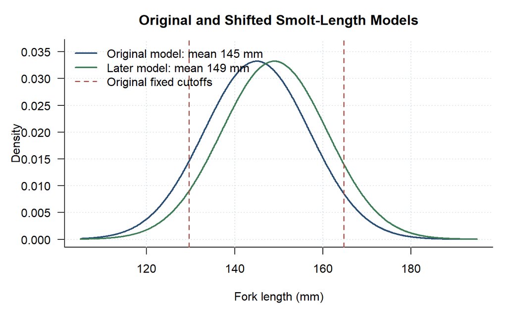